# Bayesian Modeling and Prediction for Movies

## Setup

### Load packages

```r
library(ggplot2)
library(dplyr)
library(statsr)
library(BAS)
library(tidyr)
library(grid)
library(GGally)
library(gridExtra)
library(MASS)
library(cowplot)
```

### Load data

Make sure your data and R Markdown files are in the same directory. When loaded your data file will be called `movies`. Delete this note when before you submit your work.

```r
load("movies.Rdata")
```

## Part 1: Data

This is an observational study thus we can’t infer causality based on this dataset. Random sampling are used so generazability is ensured. There might be bias in the dataset because the rating system might have bias and only US movies are included.

## Part 2: Data manipulation

```r
# Looking at the summary table of the varibales in the dataset
str(movies)
```

```
## tibble [651 x 32] (S3: tbl_df/tbl/data.frame)
##  $ title           : chr [1:651] "Filly Brown" "The Dish" "Waiting for Guffman" "The Age of Innocence" ...
##  $ title_type      : Factor w/ 3 levels "Documentary",..: 2 2 2 2 2 1 2 2 1 2 ...
##  $ genre           : Factor w/ 11 levels "Action & Adventure",..: 6 6 4 6 7 5 6 6 5 6 ...
##  $ runtime         : num [1:651] 80 101 84 139 90 78 142 93 88 119 ...
##  $ mpaa_rating     : Factor w/ 6 levels "G","NC-17","PG",..: 5 4 5 3 5 6 4 5 6 6 ...
##  $ studio          : Factor w/ 211 levels "20th Century Fox",..: 91 202 167 34 13 163 147 118 88 84 ...
##  $ thtr_rel_year   : num [1:651] 2013 2001 1996 1993 2004 ...
##  $ thtr_rel_month  : num [1:651] 4 3 8 10 9 1 1 11 9 3 ...
##  $ thtr_rel_day    : num [1:651] 19 14 21 1 10 15 1 8 7 2 ...
##  $ dvd_rel_year    : num [1:651] 2013 2001 2001 2001 2005 ...
##  $ dvd_rel_month   : num [1:651] 7 8 8 11 4 4 2 3 1 8 ...
##  $ dvd_rel_day     : num [1:651] 30 28 21 6 19 20 18 2 21 14 ...
##  $ imdb_rating     : num [1:651] 5.5 7.3 7.6 7.2 5.1 7.8 7.2 5.5 7.5 6.6 ...
##  $ imdb_num_votes  : int [1:651] 899 12285 22381 35096 2386 333 5016 2272 880 12496 ...
```

[output cut: 18 more lines]

We need to remove the `NA` values.

```r
dim(movies)
```

```
## [1] 651  32
```

```r
movies <- na.omit(movies)
dim(movies)
```

```
## [1] 619  32
```

We need to create new variables and change the format of certain variables.

```r
data_movies<-movies %>% mutate(feature_film = factor(ifelse(title_type=="Feature Film",c("yes"), c("no")),levels=c("no","yes"))) %>%
mutate(drama = factor(ifelse(genre=="Drama", c("yes"), c("no")),levels=c("no","yes")))%>%
mutate(mpaa_rating_R =factor(ifelse(mpaa_rating=="R", c("yes"), c("no")),levels=c("no","yes")))%>%
mutate(oscar_season = factor(ifelse(thtr_rel_month%in% 10:12, c("yes"), c("no")),levels=c("no","yes")))%>%
mutate(summer_season = factor(ifelse(thtr_rel_month %in% 5:8, c("yes"), c("no")),levels=c("no","yes")))
```

## Part 3: Exploratory data analysis

In this part, we need to perform exploratory data analysis on variable `audience_score` and other potential associated variables.

We first visualize the variable `audience_score`.

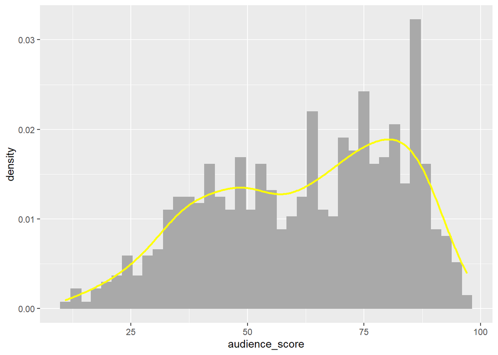

```r
ggplot(data_movies, aes(x = audience_score, y = ..density..)) +
  geom_histogram(bins = 40, fill = 'darkgrey', colour = 'darkgrey') +
  geom_density(size = 1, colour = 'yellow')
```

We could see slightly left screwed structure in `audience_score` variable. Checking some statistical values:

```r
summary(data_movies$audience_score)
```

```
##    Min. 1st Qu.  Median    Mean 3rd Qu.    Max.
##   11.00   46.00   65.00   62.21   80.00   97.00
```

Now we draw boxplots for other potential associated variables in order to illustrate their variability.

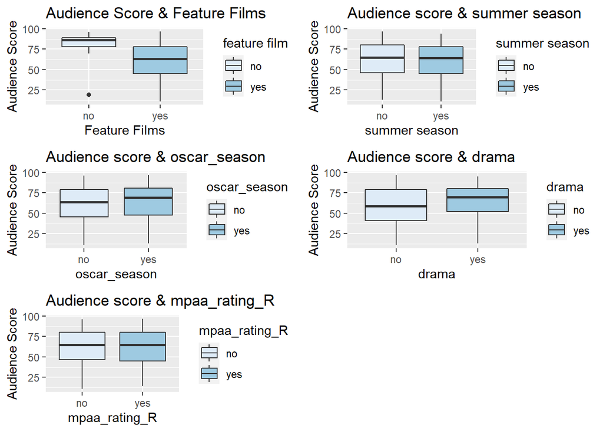

```r
p1 <- ggplot(data_movies, aes(y=audience_score, x=feature_film, fill = feature_film)) +
  geom_boxplot() +
  ggtitle("Audience Score & Feature Films") +
  xlab("Feature Films") +
  ylab("Audience Score") +
  scale_fill_brewer(name = "feature film")


p2 <- ggplot(data_movies, aes(x = summer_season, y = audience_score, fill = summer_season)) +
  geom_boxplot() +
  ggtitle('Audience score & summer season') +
  xlab('summer season') +
  ylab('Audience Score') + scale_fill_brewer(name = "summer season")


p3 <- ggplot(data_movies, aes(x = oscar_season, y = audience_score, fill = oscar_season)) +
  geom_boxplot() +
  ggtitle('Audience score & oscar_season') +
  xlab('oscar_season') +
  ylab('Audience Score') +
  scale_fill_brewer(name = "oscar_season")


p4 <- ggplot(data_movies, aes(x = drama, y = audience_score, fill = drama)) +
  geom_boxplot() +
  ggtitle('Audience score & drama') +
  xlab('drama') +
  ylab('Audience Score') +
  scale_fill_brewer(name = "drama")


p5 <- ggplot(data_movies, aes(x = mpaa_rating_R, y = audience_score, fill = mpaa_rating_R)) +
  geom_boxplot() +
  ggtitle('Audience score & mpaa_rating_R') +
  xlab('mpaa_rating_R') +
  ylab('Audience Score') +
  scale_fill_brewer(name = "mpaa_rating_R")

grid.arrange(p1, p2, p3, p4, p5, ncol = 2)
```

We could see that the `audience_score` shows smaller difference between options of `mpaa_rating_R` variable. But the audience scores are relatively higher in films that have no features and slightly higher in films no released in summer season. Films with Oscar season and belongs to drama category have higher audience scores.

We could show other variables with density plots.

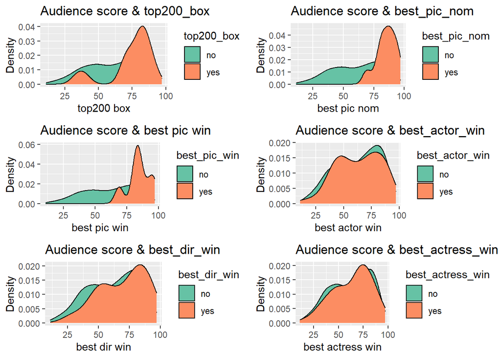

```r
p1 <- ggplot(data_movies, aes(audience_score, fill = top200_box))+
  geom_density () +
  labs(title = "Audience score & top200_box") +
  labs(x = "top200 box", y = "Density") +
  scale_fill_brewer(palette = "Set2")

p2 <- ggplot(data_movies, aes(audience_score, fill = best_pic_nom))+
  geom_density () +
  labs(title = "Audience score & best_pic_nom") +
  labs(x = "best pic nom", y = "Density") +
  scale_fill_brewer(palette = "Set2")


p3 <- ggplot(data_movies, aes(audience_score, fill = best_pic_win)) +
  geom_density() +
  labs(title = "Audience score & best pic win") +
  labs(x = "best pic win", y = "Density") +
  scale_fill_brewer(palette = "Set2")

p4 <- ggplot(data_movies, aes(audience_score, fill = best_actor_win))+
  geom_density () +
  labs(title = "Audience score & best_actor_win") +
  labs(x = "best actor win", y = "Density") +
  scale_fill_brewer(palette = "Set2")


p5 <- ggplot(data_movies, aes(audience_score, fill = best_dir_win))+
  geom_density () +
  labs(title = "Audience score & best_dir_win") +
  labs(x = "best dir win", y = "Density") +
  scale_fill_brewer(palette = "Set2")


p6 <- ggplot(data_movies, aes(audience_score, fill = best_actress_win))+
  geom_density () +
  labs(title = "Audience score & best_actress_win") +
  labs(x = "best actress win", y = "Density") +
  scale_fill_brewer(palette = "Set2")

grid.arrange(p1, p2, p3, p4, p5, p6, ncol = 2)
```

We could see that top200 movies and movies that won best picture award or have best picture nomination in Oscar have relatively higher audience scores. However, movies that won best director, actor or actress awards have slightly higher audience scores.

## Part 4: Modeling

We could use `bayes_inference` function to construct credible intervals, perform hypothesis test and calculate Bayes factors. We’d like to investigate the influence of other variables to `audience_score`.

```r
bayes_inference(y = audience_score, x = feature_film, data = data_movies, statistic = 'mean', type = 'ht', null = 0, alternative = 'twosided', prior = "JZS", rscale = 1, method = "theoretical")
```

```
## Response variable: numerical, Explanatory variable: categorical (2 levels)
## n_no = 46, y_bar_no = 82.5435, s_no = 11.9177
## n_yes = 573, y_bar_yes = 60.5777, s_yes = 19.8187
## (Assuming Zellner-Siow Cauchy prior on the difference of means. )
## (Assuming independent Jeffreys prior on the overall mean and variance. )
## Hypotheses:
## H1: mu_no  = mu_yes
## H2: mu_no != mu_yes
##
## Priors: P(H1) = 0.5  P(H2) = 0.5
##
## Results:
## BF[H2:H1] = 14614401072
## P(H1|data) = 0
## P(H2|data) = 1
##
## Posterior summaries for under H2:
## Response variable: numerical, Explanatory variable: categorical (2 levels)
## n_no = 46, y_bar_no = 82.5435, s_no = 11.9177
## n_yes = 573, y_bar_yes = 60.5777, s_yes = 19.8187
## (Assuming Zellner-Siow Cauchy prior for difference in means)
## (Assuming independent Jeffrey's priors for overall mean and variance)
##
##
## Posterior Summaries
##                       2.5%        25%        50%        75%       97.5%
## overall mean    68.4609555  70.365465  71.397811  72.438113   74.327022
## mu_no - mu_yes  15.6902527  19.499759  21.547403  23.670626   27.364712
## sigma^2        335.9328390 361.020308 375.112826 389.848670  420.258792
## effect size      0.8066229   1.006856   1.114657   1.221684    1.421411
## n_0             13.1942785 155.874994 384.925308 770.453783 2100.523852
## 95% Cred. Int.: (15.6903 , 27.3647)
```

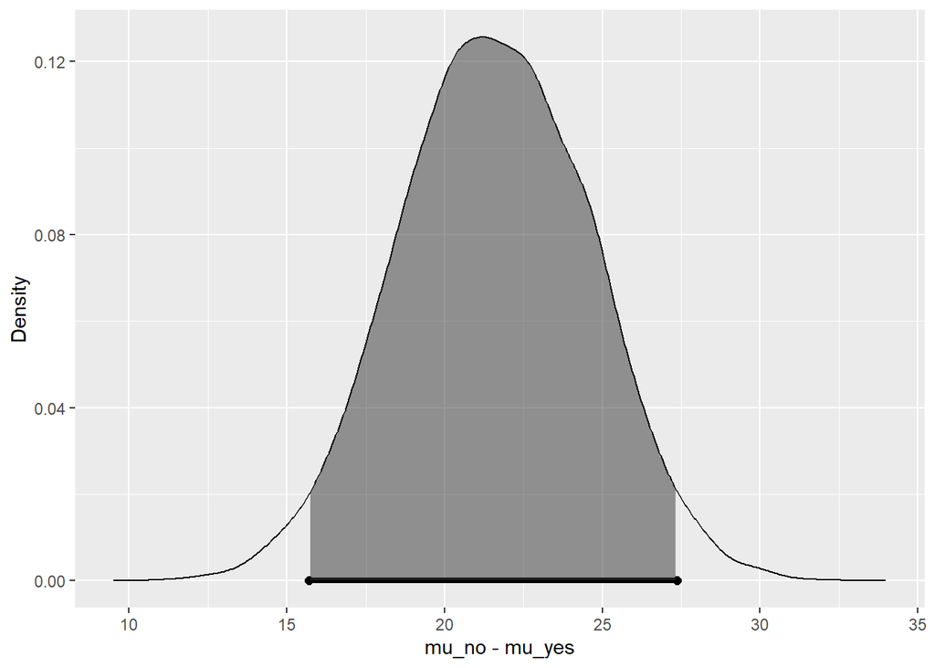

```r
bayes_inference(y = audience_score, x = drama, data = data_movies, statistic = 'mean', type = 'ht', null = 0, alternative = 'twosided', prior = "JZS", rscale = 1, method = "theoretical")
```

```
## Response variable: numerical, Explanatory variable: categorical (2 levels)
## n_no = 321, y_bar_no = 59.352, s_no = 21.1448
## n_yes = 298, y_bar_yes = 65.2886, s_yes = 18.6305
## (Assuming Zellner-Siow Cauchy prior on the difference of means. )
## (Assuming independent Jeffreys prior on the overall mean and variance. )
## Hypotheses:
## H1: mu_no  = mu_yes
## H2: mu_no != mu_yes
##
## Priors: P(H1) = 0.5  P(H2) = 0.5
##
## Results:
## BF[H2:H1] = 50.7705
## P(H1|data) = 0.0193
## P(H2|data) = 0.9807
##
## Posterior summaries for under H2:
## Response variable: numerical, Explanatory variable: categorical (2 levels)
## n_no = 321, y_bar_no = 59.352, s_no = 21.1448
## n_yes = 298, y_bar_yes = 65.2886, s_yes = 18.6305
## (Assuming Zellner-Siow Cauchy prior for difference in means)
## (Assuming independent Jeffrey's priors for overall mean and variance)
##
##
## Posterior Summaries
##                       2.5%         25%         50%          75%        97.5%
## overall mean    60.7306183  61.7699389  62.3148455   62.8592673   63.8979129
## mu_no - mu_yes  -8.9766642  -6.9441075  -5.8529572   -4.7841056   -2.7306626
## sigma^2        358.7759245 384.0207419 398.6687067  414.3436945  445.5801390
## effect size     -0.4508595  -0.3477834  -0.2932919   -0.2400417   -0.1366324
## n_0             27.7719076 335.3722206 806.4836441 1565.2743751 4251.8333285
## 95% Cred. Int.: (-8.9767 , -2.7307)
```

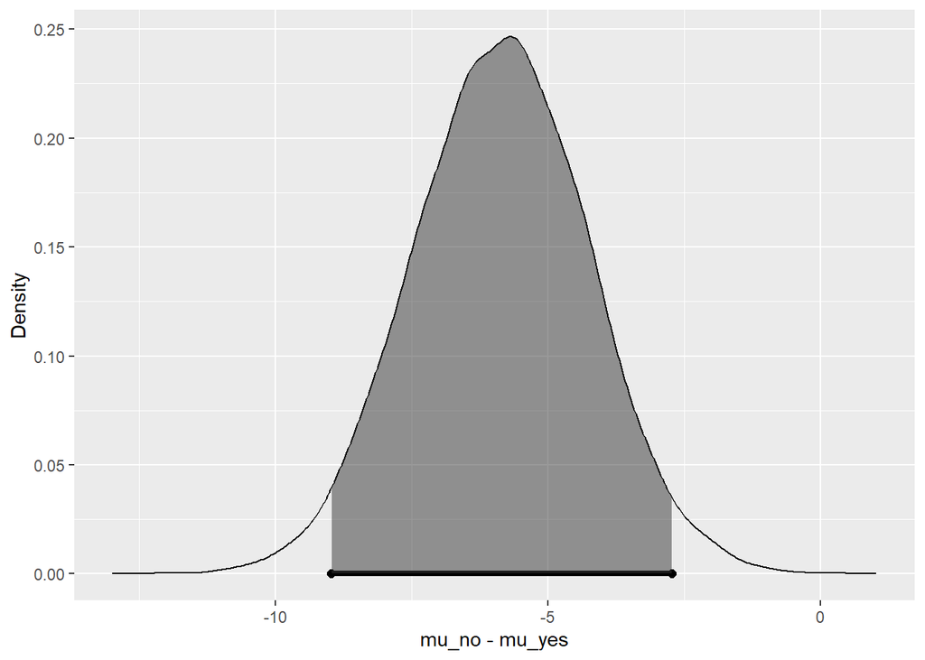

```r
bayes_inference(y = audience_score, x = oscar_season, data = data_movies, statistic = 'mean', type = 'ht', null = 0, alternative = 'twosided', prior = "JZS", rscale = 1, method = "theoretical")
```

```
## Response variable: numerical, Explanatory variable: categorical (2 levels)
## n_no = 440, y_bar_no = 61.5386, s_no = 20.107
## n_yes = 179, y_bar_yes = 63.8603, s_yes = 20.3118
## (Assuming Zellner-Siow Cauchy prior on the difference of means. )
## (Assuming independent Jeffreys prior on the overall mean and variance. )
## Hypotheses:
## H1: mu_no  = mu_yes
## H2: mu_no != mu_yes
##
## Priors: P(H1) = 0.5  P(H2) = 0.5
##
## Results:
## BF[H1:H2] = 6.2077
## P(H1|data) = 0.8613
## P(H2|data) = 0.1387
##
## Posterior summaries for under H2:
## Response variable: numerical, Explanatory variable: categorical (2 levels)
## n_no = 440, y_bar_no = 61.5386, s_no = 20.107
## n_yes = 179, y_bar_yes = 63.8603, s_yes = 20.3118
## (Assuming Zellner-Siow Cauchy prior for difference in means)
## (Assuming independent Jeffrey's priors for overall mean and variance)
##
##
## Posterior Summaries
##                       2.5%         25%         50%           75%        97.5%
## overall mean    60.9470255  62.1071548  62.7051645   63.30776675 6.446144e+01
## mu_no - mu_yes  -5.7292974  -3.4892080  -2.3003991   -1.14130077 1.092067e+00
## sigma^2        364.7075169 390.9929739 406.0823130  422.16524110 4.548073e+02
## effect size     -0.2841694  -0.1729512  -0.1145989   -0.05645475 5.379014e-02
## n_0             31.1431364 348.2123632 821.4757750 1643.68003261 4.408613e+03
## 95% Cred. Int.: (-5.7293 , 1.0921)
```

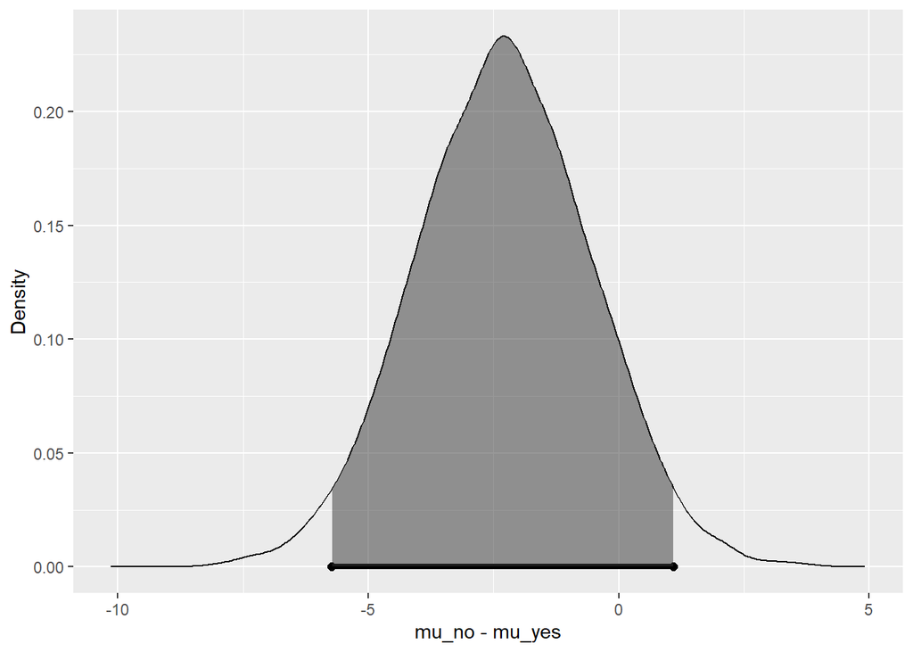

```r
bayes_inference(y = audience_score, x = summer_season, data = data_movies, statistic = 'mean', type = 'ht', null = 0, alternative = 'twosided', prior = "JZS", rscale = 1, method = "theoretical")
```

```
## Response variable: numerical, Explanatory variable: categorical (2 levels)
## n_no = 418, y_bar_no = 62.3828, s_no = 20.3266
## n_yes = 201, y_bar_yes = 61.8507, s_yes = 19.9092
## (Assuming Zellner-Siow Cauchy prior on the difference of means. )
## (Assuming independent Jeffreys prior on the overall mean and variance. )
## Hypotheses:
## H1: mu_no  = mu_yes
## H2: mu_no != mu_yes
##
## Priors: P(H1) = 0.5  P(H2) = 0.5
##
## Results:
## BF[H1:H2] = 14.0392
## P(H1|data) = 0.9335
## P(H2|data) = 0.0665
##
## Posterior summaries for under H2:
## Response variable: numerical, Explanatory variable: categorical (2 levels)
## n_no = 418, y_bar_no = 62.3828, s_no = 20.3266
## n_yes = 201, y_bar_yes = 61.8507, s_yes = 19.9092
## (Assuming Zellner-Siow Cauchy prior for difference in means)
## (Assuming independent Jeffrey's priors for overall mean and variance)
##
##
## Posterior Summaries
##                       2.5%         25%         50%          75%        97.5%
## overall mean    60.4334722  61.5421531  62.1233215 6.270865e+01   63.8249407
## mu_no - mu_yes  -2.8556077  -0.5958449   0.5523637 1.699824e+00    3.8551664
## sigma^2        364.9276494 392.0256503 407.1729984 4.237507e+02  457.2410365
## effect size     -0.1406039  -0.0294578   0.0272284 8.406838e-02    0.1899113
## n_0             31.5804084 356.6558184 867.2263501 1.703627e+03 4376.1286834
## 95% Cred. Int.: (-2.8556 , 3.8552)
```

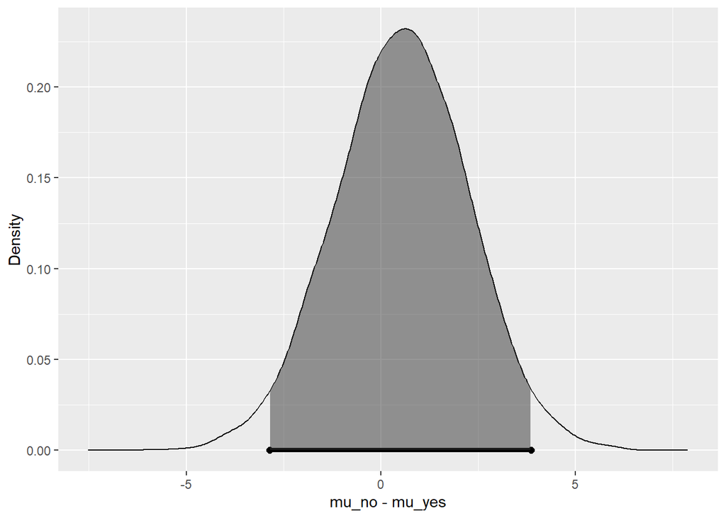

```r
bayes_inference(y = audience_score, x = mpaa_rating_R, data = data_movies, statistic = 'mean', type = 'ht', null = 0, alternative = 'twosided', prior = "JZS", rscale = 1, method = "theoretical")
```

```
## Response variable: numerical, Explanatory variable: categorical (2 levels)
## n_no = 300, y_bar_no = 62.0367, s_no = 20.3187
## n_yes = 319, y_bar_yes = 62.373, s_yes = 20.0743
## (Assuming Zellner-Siow Cauchy prior on the difference of means. )
## (Assuming independent Jeffreys prior on the overall mean and variance. )
## Hypotheses:
## H1: mu_no  = mu_yes
## H2: mu_no != mu_yes
##
## Priors: P(H1) = 0.5  P(H2) = 0.5
##
## Results:
## BF[H1:H2] = 15.354
## P(H1|data) = 0.9389
## P(H2|data) = 0.0611
##
## Posterior summaries for under H2:
## Response variable: numerical, Explanatory variable: categorical (2 levels)
## n_no = 300, y_bar_no = 62.0367, s_no = 20.3187
## n_yes = 319, y_bar_yes = 62.373, s_yes = 20.0743
## (Assuming Zellner-Siow Cauchy prior for difference in means)
## (Assuming independent Jeffrey's priors for overall mean and variance)
##
##
## Posterior Summaries
##                       2.5%          25%          50%          75%        97.5%
## overall mean    60.6069115  61.65725840  62.20655049 6.275426e+01   63.8191740
## mu_no - mu_yes  -3.4394061  -1.43074126  -0.32070653 7.581125e-01    2.8256648
## sigma^2        365.4059896 391.75889757 407.45517185 4.233177e+02  454.5822973
## effect size     -0.1719883  -0.07094362  -0.01597138 3.762447e-02    0.1404154
## n_0             33.3322328 361.42049459 856.34207505 1.689214e+03 4530.1079989
## 95% Cred. Int.: (-3.4394 , 2.8257)
```

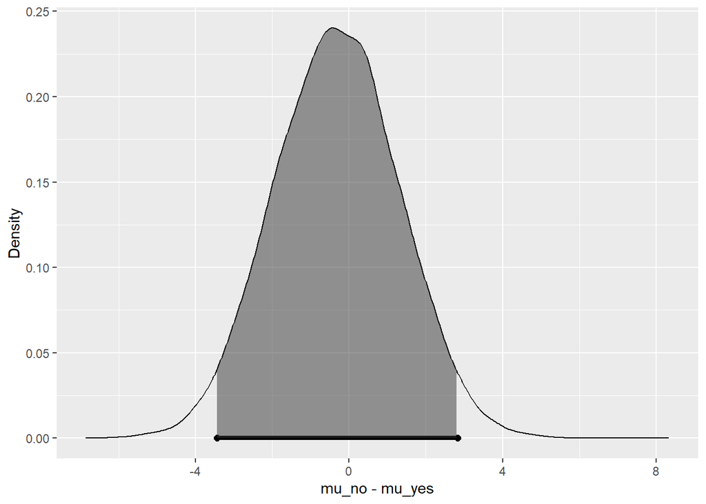

Checking the value of Bayes factors.

We could find significant difference of audience scores in feature and non-feature films.

## Part 5: Prediction

In this part we first filter siginificant variables.

```r
data.model <- data_movies[c("feature_film","drama","runtime","mpaa_rating_R","thtr_rel_year","oscar_season","summer_season","imdb_rating","imdb_num_votes","critics_score","best_pic_nom","best_pic_win","best_actor_win","best_actress_win","best_dir_win","top200_box","audience_score")]

str(data.model)
```

```
## tibble [619 x 17] (S3: tbl_df/tbl/data.frame)
##  $ feature_film    : Factor w/ 2 levels "no","yes": 2 2 2 2 2 2 2 1 2 2 ...
##  $ drama           : Factor w/ 2 levels "no","yes": 2 2 1 2 1 2 2 1 2 1 ...
##  $ runtime         : num [1:619] 80 101 84 139 90 142 93 88 119 127 ...
##  $ mpaa_rating_R   : Factor w/ 2 levels "no","yes": 2 1 2 1 2 1 2 1 1 1 ...
##  $ thtr_rel_year   : num [1:619] 2013 2001 1996 1993 2004 ...
##  $ oscar_season    : Factor w/ 2 levels "no","yes": 1 1 1 2 1 1 2 1 1 1 ...
##  $ summer_season   : Factor w/ 2 levels "no","yes": 1 1 2 1 1 1 1 1 1 2 ...
##  $ imdb_rating     : num [1:619] 5.5 7.3 7.6 7.2 5.1 7.2 5.5 7.5 6.6 6.8 ...
##  $ imdb_num_votes  : int [1:619] 899 12285 22381 35096 2386 5016 2272 880 12496 71979 ...
##  $ critics_score   : num [1:619] 45 96 91 80 33 57 17 90 83 89 ...
##  $ best_pic_nom    : Factor w/ 2 levels "no","yes": 1 1 1 1 1 1 1 1 1 1 ...
##  $ best_pic_win    : Factor w/ 2 levels "no","yes": 1 1 1 1 1 1 1 1 1 1 ...
##  $ best_actor_win  : Factor w/ 2 levels "no","yes": 1 1 1 2 1 1 2 1 1 2 ...
##  $ best_actress_win: Factor w/ 2 levels "no","yes": 1 1 1 1 1 1 1 1 1 1 ...
##  $ best_dir_win    : Factor w/ 2 levels "no","yes": 1 1 1 2 1 1 1 1 1 1 ...
##  $ top200_box      : Factor w/ 2 levels "no","yes": 1 1 1 1 1 1 1 1 1 2 ...
##  $ audience_score  : num [1:619] 73 81 91 76 27 76 47 89 66 75 ...
##  - attr(*, "na.action")= 'omit' Named int [1:32] 6 25 94 100 131 172 175 184 198 207 ...
##   ..- attr(*, "names")= chr [1:32] "6" "25" "94" "100" ...
```

```r
lm_model <- lm(audience_score ~ ., data = data.model)
score_step <- stepAIC(lm_model, trace = FALSE)
score_step$anova
```

```
## Stepwise Model Path
## Analysis of Deviance Table
##
## Initial Model:
## audience_score ~ feature_film + drama + runtime + mpaa_rating_R +
##     thtr_rel_year + oscar_season + summer_season + imdb_rating +
##     imdb_num_votes + critics_score + best_pic_nom + best_pic_win +
##     best_actor_win + best_actress_win + best_dir_win + top200_box
##
## Final Model:
## audience_score ~ runtime + mpaa_rating_R + imdb_rating + critics_score +
##     best_pic_nom + best_actress_win
##
##
##                Step Df   Deviance Resid. Df Resid. Dev      AIC
## 1                                       602   61285.24 2878.422
## 2      - top200_box  1   8.158011       603   61293.40 2876.504
## 3    - oscar_season  1   9.834264       604   61303.24 2874.604
## 4    - best_pic_win  1  43.432561       605   61346.67 2873.042
## 5    - best_dir_win  1  91.172934       606   61437.84 2871.961
## 6  - best_actor_win  1 125.157576       607   61563.00 2871.221
## 7   - summer_season  1 176.422141       608   61739.42 2870.992
## 8    - feature_film  1 188.009104       609   61927.43 2870.875
## 9           - drama  1 124.155090       610   62051.59 2870.114
## 10 - imdb_num_votes  1 167.442064       611   62219.03 2869.782
## 11  - thtr_rel_year  1 168.854308       612   62387.88 2869.460
```

```r
BMA_audience_score <- bas.lm(audience_score ~., data = data.model, prior = "BIC", modelprior = uniform())
summary(BMA_audience_score)
```

```
##                     P(B != 0 | Y)    model 1       model 2       model 3
## Intercept              1.00000000     1.0000     1.0000000     1.0000000
## feature_filmyes        0.05876309     0.0000     0.0000000     0.0000000
## dramayes               0.04508592     0.0000     0.0000000     0.0000000
## runtime                0.51399873     1.0000     0.0000000     0.0000000
## mpaa_rating_Ryes       0.16498090     0.0000     0.0000000     0.0000000
## thtr_rel_year          0.08088668     0.0000     0.0000000     0.0000000
## oscar_seasonyes        0.06525993     0.0000     0.0000000     0.0000000
## summer_seasonyes       0.07935408     0.0000     0.0000000     0.0000000
## imdb_rating            1.00000000     1.0000     1.0000000     1.0000000
## imdb_num_votes         0.06242230     0.0000     0.0000000     0.0000000
## critics_score          0.92015573     1.0000     1.0000000     1.0000000
## best_pic_nomyes        0.13200908     0.0000     0.0000000     0.0000000
## best_pic_winyes        0.04076727     0.0000     0.0000000     0.0000000
## best_actor_winyes      0.11565473     0.0000     0.0000000     0.0000000
## best_actress_winyes    0.14770126     0.0000     0.0000000     1.0000000
## best_dir_winyes        0.06701259     0.0000     0.0000000     0.0000000
## top200_boxyes          0.04875994     0.0000     0.0000000     0.0000000
## BF                             NA     1.0000     0.8715404     0.2048238
## PostProbs                      NA     0.1558     0.1358000     0.0319000
## R2                             NA     0.7483     0.7455000     0.7470000
## dim                            NA     4.0000     3.0000000     4.0000000
## logmarg                        NA -3434.7520 -3434.8894481 -3436.3375603
##                           model 4       model 5
## Intercept               1.0000000     1.0000000
## feature_filmyes         0.0000000     0.0000000
## dramayes                0.0000000     0.0000000
## runtime                 1.0000000     1.0000000
## mpaa_rating_Ryes        1.0000000     0.0000000
## thtr_rel_year           0.0000000     0.0000000
## oscar_seasonyes         0.0000000     0.0000000
## summer_seasonyes        0.0000000     0.0000000
## imdb_rating             1.0000000     1.0000000
## imdb_num_votes          0.0000000     0.0000000
## critics_score           1.0000000     1.0000000
## best_pic_nomyes         0.0000000     1.0000000
## best_pic_winyes         0.0000000     0.0000000
## best_actor_winyes       0.0000000     0.0000000
## best_actress_winyes     0.0000000     0.0000000
## best_dir_winyes         0.0000000     0.0000000
## top200_boxyes           0.0000000     0.0000000
## BF                      0.2039916     0.1851908
## PostProbs               0.0318000     0.0289000
## R2                      0.7496000     0.7495000
## dim                     5.0000000     5.0000000
## logmarg             -3436.3416317 -3436.4383237
```

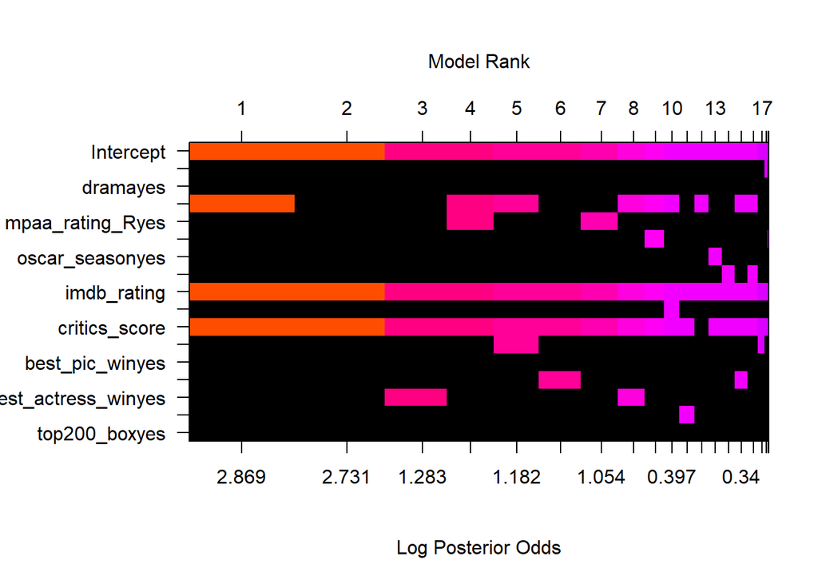

```r
image(BMA_audience_score, rotate = FALSE)
```

The figure illustrates `runtime`, `imdb_rating` and `critic_score` have higher posterior odds.

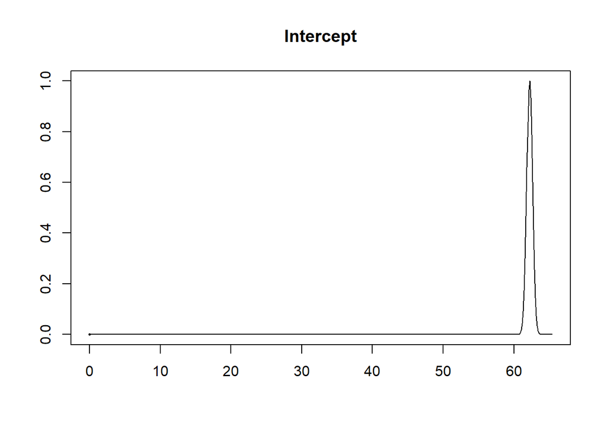

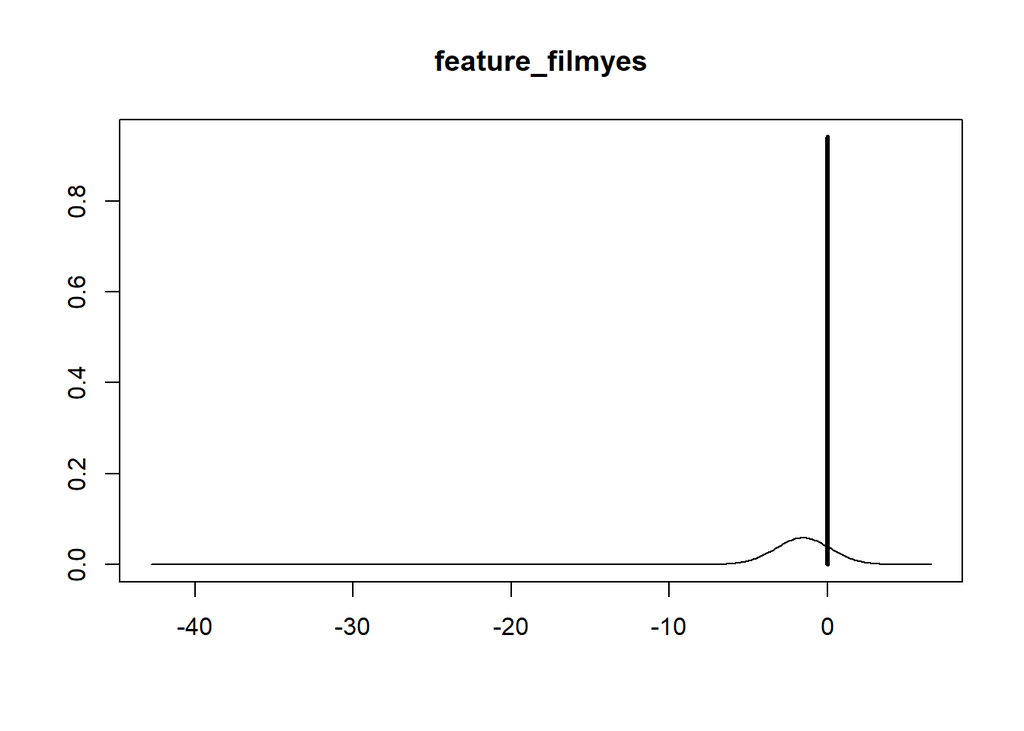

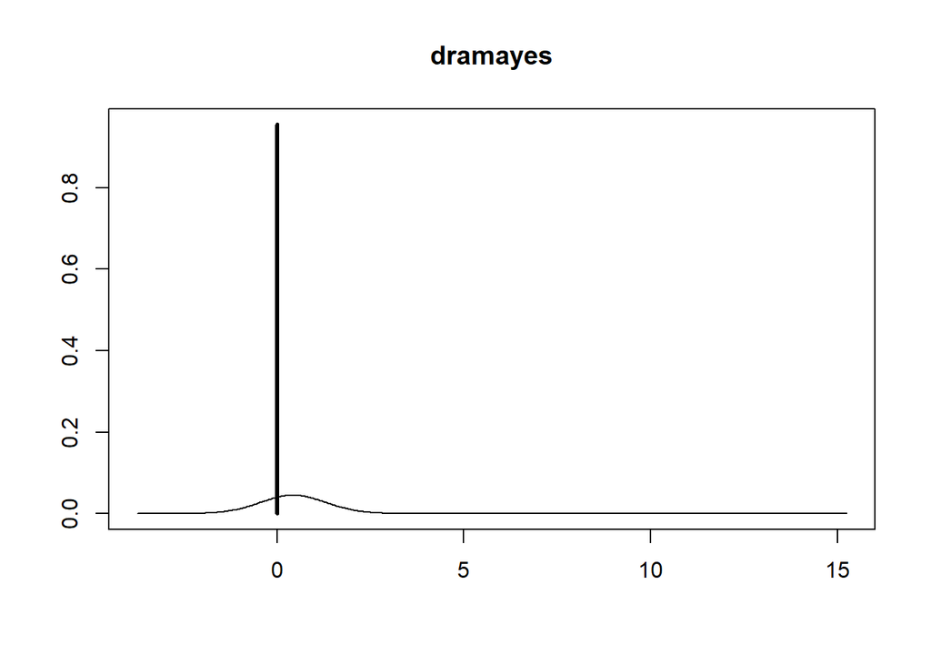

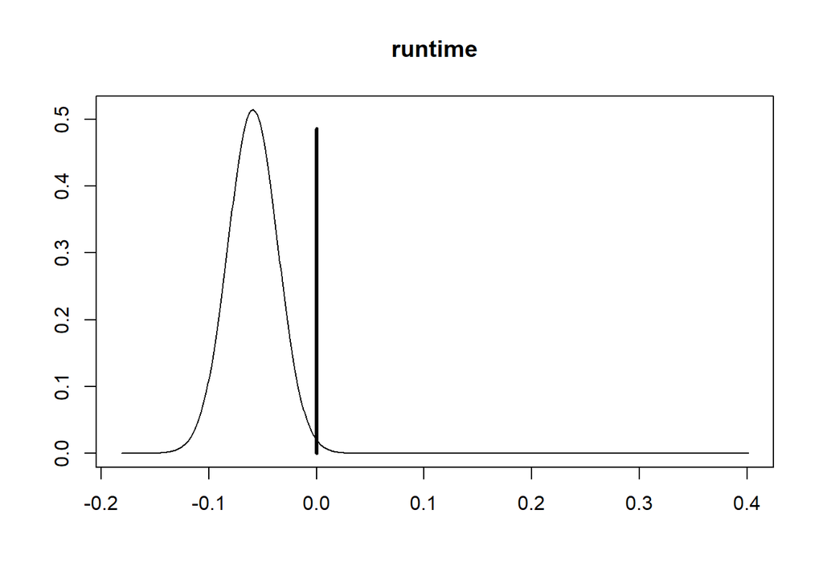

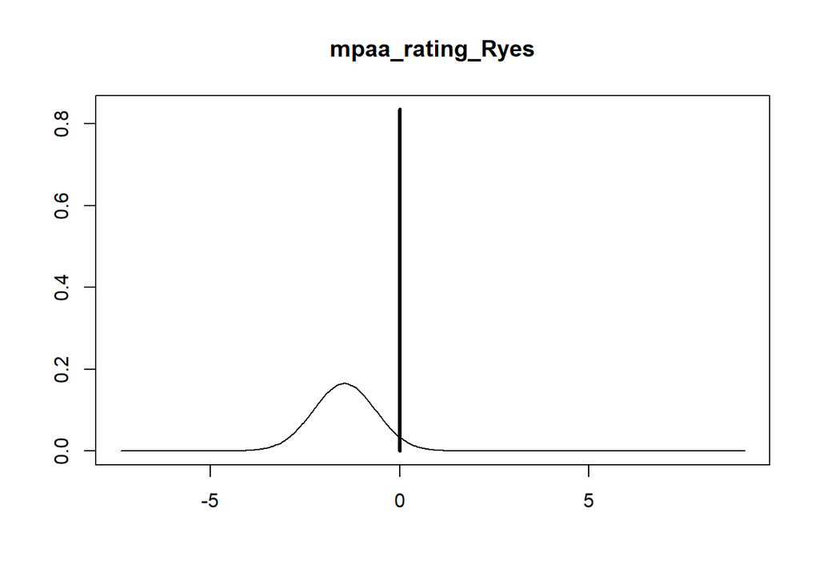

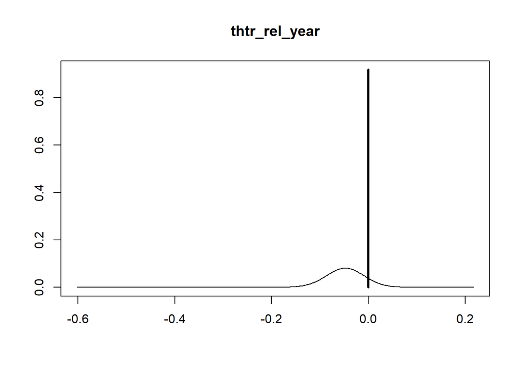

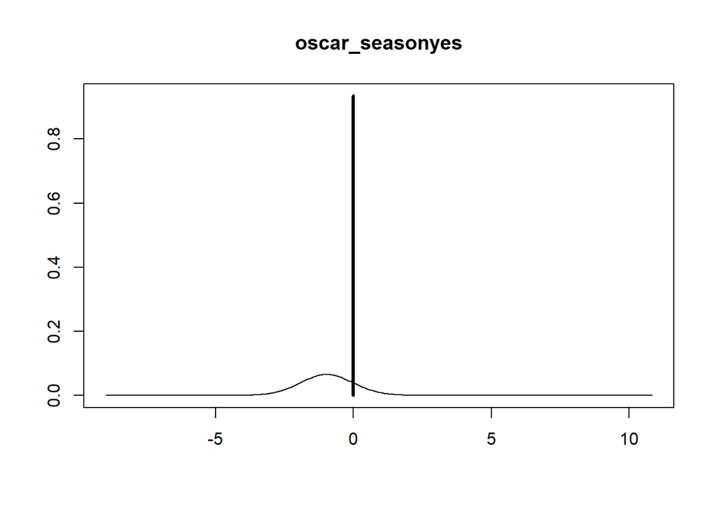

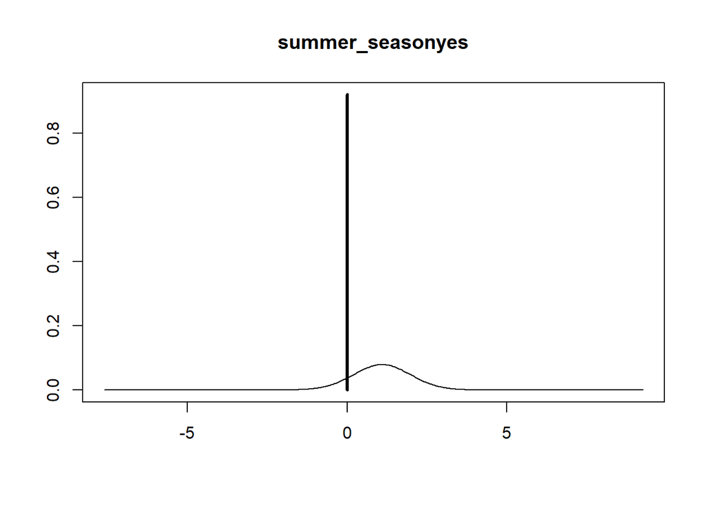

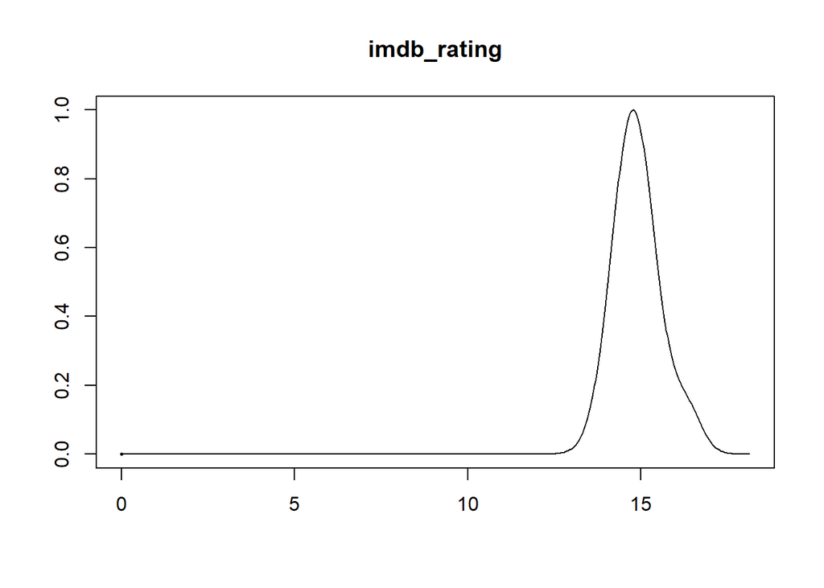

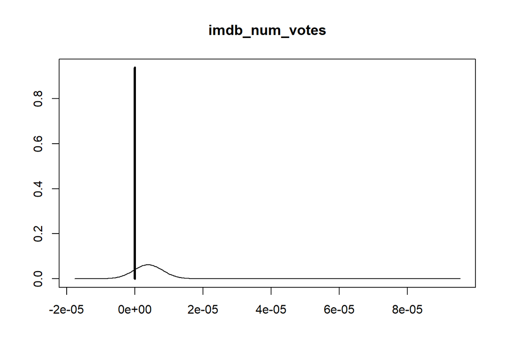

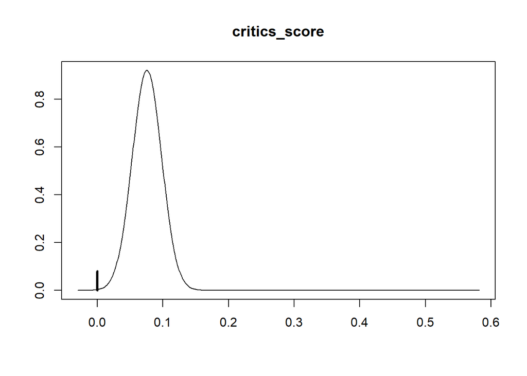

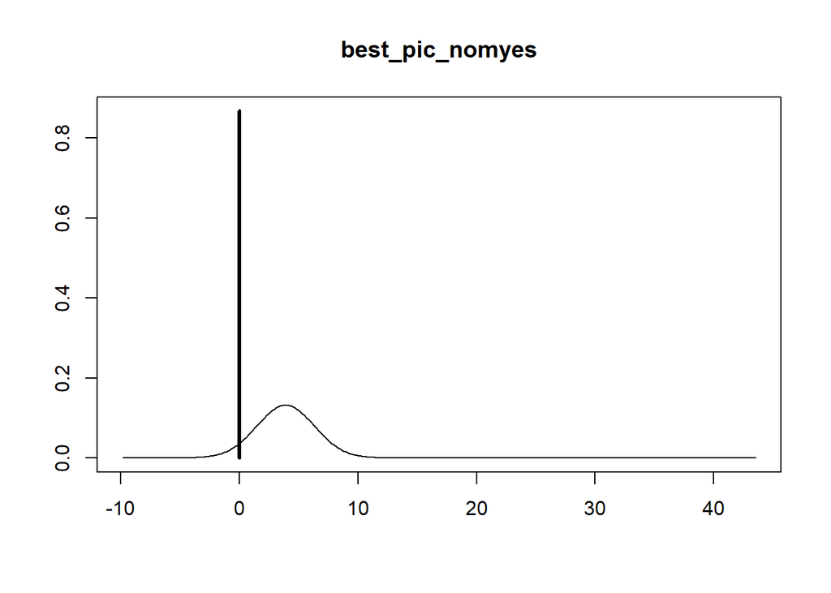

[5 more figures not shown]

```r
coef_BMA_audience_score <- coef(BMA_audience_score)
plot(coef_BMA_audience_score)
```

We will kept the three variables we mentioned before in the final model.

```r
finalmodel <- data.model[c("runtime","imdb_rating","critics_score","audience_score")]

BMA_finalmodel <- bas.lm(audience_score ~., data = finalmodel, prior = "ZS-null", method = "MCMC", modelprior = uniform())

summary(BMA_finalmodel)
```

```
##               P(B != 0 | Y)  model 1     model 2      model 3      model 4
## Intercept           1.00000   1.0000   1.0000000   1.00000000   1.00000000
## runtime             0.62500   1.0000   0.0000000   1.00000000   0.00000000
## imdb_rating         1.00000   1.0000   1.0000000   1.00000000   1.00000000
## critics_score       0.93125   1.0000   1.0000000   0.00000000   0.00000000
## BF                       NA   1.0000   0.9928814   0.09635143   0.08035048
## PostProbs                NA   0.5714   0.3540000   0.04970000   0.01860000
## R2                       NA   0.7483   0.7455000   0.74360000   0.74050000
## dim                      NA   4.0000   3.0000000   3.00000000   2.00000000
## logmarg                  NA 413.8820 413.8748206 411.54221157 411.36060745
##                     model 5
## Intercept      1.000000e+00
## runtime        0.000000e+00
## imdb_rating    0.000000e+00
## critics_score  0.000000e+00
## BF            1.792035e-180
## PostProbs      6.200000e-03
## R2             0.000000e+00
## dim            1.000000e+00
## logmarg        0.000000e+00
```

## Part 6: Conclusion

We choose a famous film “La La Land (2016)” and predict its audience score.

```r
lalaland <- data.frame(feature_film="yes",drama="yes",runtime=128,mpaa_rating_R="no",thtr_rel_year=2016,oscar_season="yes",summer_season="no",imdb_rating=8.1,imdb_num_votes=310814,critics_score=93,best_pic_nom="yes",best_pic_win="yes",best_actor_win="yes",best_actress_win="yes",best_dir_win="yes",top200_box="yes",audience_score=81)

data.predict <- rbind(data.model, lalaland)
lalaland <- tail(lalaland, 1)
str(lalaland)
```

```
## 'data.frame':    1 obs. of  17 variables:
##  $ feature_film    : chr "yes"
##  $ drama           : chr "yes"
##  $ runtime         : num 128
##  $ mpaa_rating_R   : chr "no"
##  $ thtr_rel_year   : num 2016
##  $ oscar_season    : chr "yes"
##  $ summer_season   : chr "no"
##  $ imdb_rating     : num 8.1
##  $ imdb_num_votes  : num 310814
##  $ critics_score   : num 93
##  $ best_pic_nom    : chr "yes"
##  $ best_pic_win    : chr "yes"
##  $ best_actor_win  : chr "yes"
##  $ best_actress_win: chr "yes"
##  $ best_dir_win    : chr "yes"
##  $ top200_box      : chr "yes"
##  $ audience_score  : num 81
```

We predict the audience score.

```r
audience_score_prediction <-predict(BMA_finalmodel, newdata=lalaland, estimator="BMA", se.fit=TRUE, interval="predict", level = 0.95)

audience_score_prediction$fit
```

```
## [1] 87.84877
```